# Risk Factor Analysis

## Outcome Variable

**Outcome Variable:** ever_sstunted

## Predictor Variables

**Intervention Variable:** hfoodsec

**Adjustment Set:**

- arm
- sex
- W_mage
- meducyrs
- feducyrs
- hhwealth_quart
- vagbrth
- W_nrooms
- W_nchldlt5
- brthmon
- W_parity
- impfloor
- impsan
- safeh20
- delta_W_mage
- delta_meducyrs
- delta_feducyrs
- delta_hhwealth_quart
- delta_vagbrth
- delta_W_nrooms
- delta_W_nchldlt5
- delta_brthmon
- delta_W_parity
- delta_impfloor
- delta_impsan
- delta_safeh20

## Stratifying Variables

The analysis was stratified on these variable(s):

- agecat
- studyid
- country

## Data Summary

| agecat | studyid | country | hfoodsec | ever_sstunted | n_cell | n |
| --- | --- | --- | --- | --- | --- | --- |
| 0-24 months | GMS-Nepal | NEPAL | Food Secure | 0 | 368 | 674 |
| 0-24 months | GMS-Nepal | NEPAL | Food Secure | 1 | 111 | 674 |
| 0-24 months | GMS-Nepal | NEPAL | Mildly Food Insecure | 0 | 77 | 674 |
| 0-24 months | GMS-Nepal | NEPAL | Mildly Food Insecure | 1 | 29 | 674 |
| 0-24 months | GMS-Nepal | NEPAL | Food Insecure | 0 | 66 | 674 |
| 0-24 months | GMS-Nepal | NEPAL | Food Insecure | 1 | 23 | 674 |
| 0-24 months | JiVitA-3 | BANGLADESH | Food Secure | 0 | 7235 | 17380 |
| 0-24 months | JiVitA-3 | BANGLADESH | Food Secure | 1 | 1464 | 17380 |
| 0-24 months | JiVitA-3 | BANGLADESH | Mildly Food Insecure | 0 | 4642 | 17380 |
| 0-24 months | JiVitA-3 | BANGLADESH | Mildly Food Insecure | 1 | 1143 | 17380 |
| 0-24 months | JiVitA-3 | BANGLADESH | Food Insecure | 0 | 2222 | 17380 |
| 0-24 months | JiVitA-3 | BANGLADESH | Food Insecure | 1 | 674 | 17380 |
| 0-24 months | JiVitA-4 | BANGLADESH | Food Secure | 0 | 2193 | 5398 |
| 0-24 months | JiVitA-4 | BANGLADESH | Food Secure | 1 | 556 | 5398 |
| 0-24 months | JiVitA-4 | BANGLADESH | Mildly Food Insecure | 0 | 1528 | 5398 |
| 0-24 months | JiVitA-4 | BANGLADESH | Mildly Food Insecure | 1 | 419 | 5398 |
| 0-24 months | JiVitA-4 | BANGLADESH | Food Insecure | 0 | 580 | 5398 |
| 0-24 months | JiVitA-4 | BANGLADESH | Food Insecure | 1 | 122 | 5398 |
| 0-24 months | MAL-ED | BANGLADESH | Food Secure | 0 | 131 | 194 |
| 0-24 months | MAL-ED | BANGLADESH | Food Secure | 1 | 30 | 194 |
| 0-24 months | MAL-ED | BANGLADESH | Mildly Food Insecure | 0 | 2 | 194 |
| 0-24 months | MAL-ED | BANGLADESH | Mildly Food Insecure | 1 | 2 | 194 |
| 0-24 months | MAL-ED | BANGLADESH | Food Insecure | 0 | 17 | 194 |
| 0-24 months | MAL-ED | BANGLADESH | Food Insecure | 1 | 12 | 194 |
| 0-24 months | MAL-ED | BRAZIL | Food Secure | 0 | 3 | 129 |
| 0-24 months | MAL-ED | BRAZIL | Food Secure | 1 | 0 | 129 |
| 0-24 months | MAL-ED | BRAZIL | Mildly Food Insecure | 0 | 9 | 129 |
| 0-24 months | MAL-ED | BRAZIL | Mildly Food Insecure | 1 | 2 | 129 |
| 0-24 months | MAL-ED | BRAZIL | Food Insecure | 0 | 104 | 129 |
| 0-24 months | MAL-ED | BRAZIL | Food Insecure | 1 | 11 | 129 |
| 0-24 months | MAL-ED | INDIA | Food Secure | 0 | 143 | 212 |
| 0-24 months | MAL-ED | INDIA | Food Secure | 1 | 47 | 212 |
| 0-24 months | MAL-ED | INDIA | Mildly Food Insecure | 0 | 4 | 212 |
| 0-24 months | MAL-ED | INDIA | Mildly Food Insecure | 1 | 1 | 212 |
| 0-24 months | MAL-ED | INDIA | Food Insecure | 0 | 13 | 212 |
| 0-24 months | MAL-ED | INDIA | Food Insecure | 1 | 4 | 212 |
| 0-24 months | MAL-ED | NEPAL | Food Secure | 0 | 86 | 128 |
| 0-24 months | MAL-ED | NEPAL | Food Secure | 1 | 8 | 128 |
| 0-24 months | MAL-ED | NEPAL | Mildly Food Insecure | 0 | 15 | 128 |
| 0-24 months | MAL-ED | NEPAL | Mildly Food Insecure | 1 | 0 | 128 |
| 0-24 months | MAL-ED | NEPAL | Food Insecure | 0 | 13 | 128 |
| 0-24 months | MAL-ED | NEPAL | Food Insecure | 1 | 6 | 128 |
| 0-24 months | MAL-ED | PERU | Food Secure | 0 | 18 | 113 |
| 0-24 months | MAL-ED | PERU | Food Secure | 1 | 9 | 113 |
| 0-24 months | MAL-ED | PERU | Mildly Food Insecure | 0 | 24 | 113 |
| 0-24 months | MAL-ED | PERU | Mildly Food Insecure | 1 | 5 | 113 |
| 0-24 months | MAL-ED | PERU | Food Insecure | 0 | 39 | 113 |
| 0-24 months | MAL-ED | PERU | Food Insecure | 1 | 18 | 113 |
| 0-24 months | MAL-ED | SOUTH AFRICA | Food Secure | 0 | 97 | 233 |
| 0-24 months | MAL-ED | SOUTH AFRICA | Food Secure | 1 | 35 | 233 |
| 0-24 months | MAL-ED | SOUTH AFRICA | Mildly Food Insecure | 0 | 14 | 233 |
| 0-24 months | MAL-ED | SOUTH AFRICA | Mildly Food Insecure | 1 | 5 | 233 |
| 0-24 months | MAL-ED | SOUTH AFRICA | Food Insecure | 0 | 58 | 233 |
| 0-24 months | MAL-ED | SOUTH AFRICA | Food Insecure | 1 | 24 | 233 |
| 0-24 months | NIH-Birth | BANGLADESH | Food Secure | 0 | 77 | 629 |
| 0-24 months | NIH-Birth | BANGLADESH | Food Secure | 1 | 18 | 629 |
| 0-24 months | NIH-Birth | BANGLADESH | Mildly Food Insecure | 0 | 339 | 629 |
| 0-24 months | NIH-Birth | BANGLADESH | Mildly Food Insecure | 1 | 153 | 629 |
| 0-24 months | NIH-Birth | BANGLADESH | Food Insecure | 0 | 17 | 629 |
| 0-24 months | NIH-Birth | BANGLADESH | Food Insecure | 1 | 25 | 629 |
| 0-24 months | NIH-Crypto | BANGLADESH | Food Secure | 0 | 400 | 758 |
| 0-24 months | NIH-Crypto | BANGLADESH | Food Secure | 1 | 53 | 758 |
| 0-24 months | NIH-Crypto | BANGLADESH | Mildly Food Insecure | 0 | 191 | 758 |
| 0-24 months | NIH-Crypto | BANGLADESH | Mildly Food Insecure | 1 | 28 | 758 |
| 0-24 months | NIH-Crypto | BANGLADESH | Food Insecure | 0 | 68 | 758 |
| 0-24 months | NIH-Crypto | BANGLADESH | Food Insecure | 1 | 18 | 758 |

The following strata were considered:

- agecat: 0-24 months, studyid: GMS-Nepal, country: NEPAL
- agecat: 0-24 months, studyid: JiVitA-3, country: BANGLADESH
- agecat: 0-24 months, studyid: JiVitA-4, country: BANGLADESH
- agecat: 0-24 months, studyid: MAL-ED, country: BANGLADESH
- agecat: 0-24 months, studyid: MAL-ED, country: BRAZIL
- agecat: 0-24 months, studyid: MAL-ED, country: INDIA
- agecat: 0-24 months, studyid: MAL-ED, country: NEPAL
- agecat: 0-24 months, studyid: MAL-ED, country: PERU
- agecat: 0-24 months, studyid: MAL-ED, country: SOUTH AFRICA
- agecat: 0-24 months, studyid: NIH-Birth, country: BANGLADESH
- agecat: 0-24 months, studyid: NIH-Crypto, country: BANGLADESH

### Dropped Strata

Some strata were dropped due to rare outcomes:

- agecat: 0-24 months, studyid: MAL-ED, country: BANGLADESH
- agecat: 0-24 months, studyid: MAL-ED, country: BRAZIL
- agecat: 0-24 months, studyid: MAL-ED, country: INDIA
- agecat: 0-24 months, studyid: MAL-ED, country: NEPAL

## Methods Detail

We're interested in the causal parameters $E[Y_a]$ for all values of $a \in \mathcal{A}$. These parameters represent the mean outcome if, possibly contrary to fact, we intervened to set all units to have $A=a$. Under the randomization and positivity assumptions, these are identified by the statistical parameters $\psi_a=E_W[E_{Y|A,W}(Y|A=a,W)]$. In addition, we're interested in the mean of $Y$, $E[Y]$ under no intervention (the observed mean). We will estimate these parameters by using SuperLearner to fit the relevant likelihood factors -- $E_{Y|A,W}(Y|A=a,W)$ and $p(A=a|W)$, and then updating our likelihood fit using a joint TMLE.

For unadjusted analyses ($W=\{\}$), initial likelihoods were estimated using Lrnr_glm to estimate the simple $E(Y|A)$ and Lrnr_mean to estimate $p(A)$. For adjusted analyses, a small library containing Lrnr_glmnet, Lrnr_xgboost, and Lrnr_mean was used.

Having estimated these parameters, we will then use the delta method to estimate relative risks and attributable risks relative to a prespecified baseline level of $A$.

# Results Detail

## Results Plots

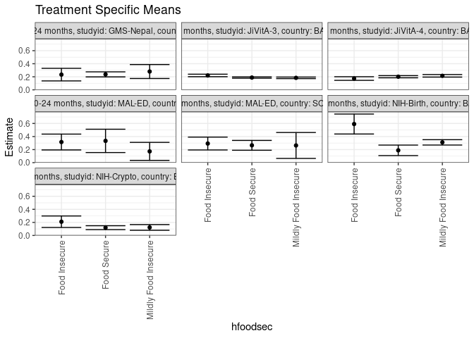

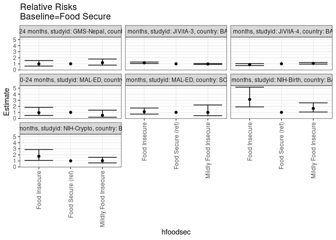

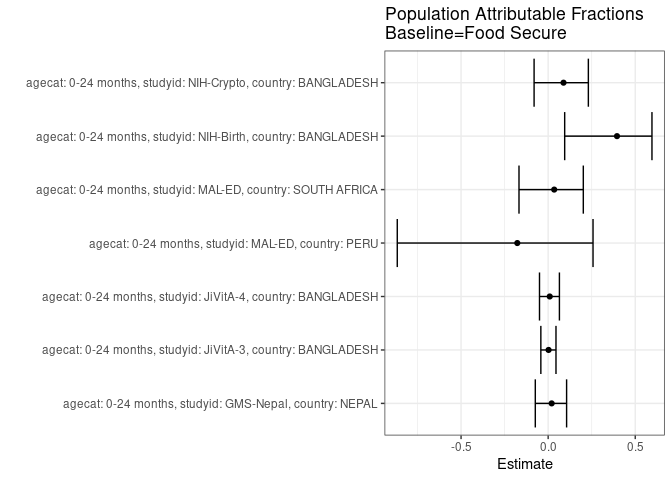

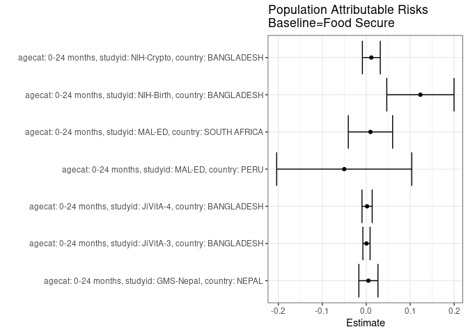

## Results Table

### Parameter: TSM

| agecat | studyid | country | intervention_level | baseline_level | estimate | ci_lower | ci_upper |
| --- | --- | --- | --- | --- | --- | --- | --- |
| 0-24 months | GMS-Nepal | NEPAL | Food Secure | NA | 0.2369675 | 0.1983143 | 0.2756207 |
| 0-24 months | GMS-Nepal | NEPAL | Mildly Food Insecure | NA | 0.2806795 | 0.1738996 | 0.3874593 |
| 0-24 months | GMS-Nepal | NEPAL | Food Insecure | NA | 0.2331752 | 0.1367290 | 0.3296214 |
| 0-24 months | JiVitA-3 | BANGLADESH | Food Secure | NA | 0.1883202 | 0.1778437 | 0.1987967 |
| 0-24 months | JiVitA-3 | BANGLADESH | Mildly Food Insecure | NA | 0.1838338 | 0.1720266 | 0.1956411 |
| 0-24 months | JiVitA-3 | BANGLADESH | Food Insecure | NA | 0.2204075 | 0.2011944 | 0.2396206 |
| 0-24 months | JiVitA-4 | BANGLADESH | Food Secure | NA | 0.2013706 | 0.1845843 | 0.2181569 |
| 0-24 months | JiVitA-4 | BANGLADESH | Mildly Food Insecure | NA | 0.2150004 | 0.1953945 | 0.2346063 |
| 0-24 months | JiVitA-4 | BANGLADESH | Food Insecure | NA | 0.1732268 | 0.1454563 | 0.2009973 |
| 0-24 months | MAL-ED | PERU | Food Secure | NA | 0.3333333 | 0.1547298 | 0.5119369 |
| 0-24 months | MAL-ED | PERU | Mildly Food Insecure | NA | 0.1724138 | 0.0343207 | 0.3105069 |
| 0-24 months | MAL-ED | PERU | Food Insecure | NA | 0.3157895 | 0.1945806 | 0.4369984 |
| 0-24 months | MAL-ED | SOUTH AFRICA | Food Secure | NA | 0.2651515 | 0.1896873 | 0.3406157 |
| 0-24 months | MAL-ED | SOUTH AFRICA | Mildly Food Insecure | NA | 0.2631579 | 0.0647309 | 0.4615849 |
| 0-24 months | MAL-ED | SOUTH AFRICA | Food Insecure | NA | 0.2926829 | 0.1939912 | 0.3913747 |
| 0-24 months | NIH-Birth | BANGLADESH | Food Secure | NA | 0.1884441 | 0.1081386 | 0.2687497 |
| 0-24 months | NIH-Birth | BANGLADESH | Mildly Food Insecure | NA | 0.3108747 | 0.2698876 | 0.3518619 |
| 0-24 months | NIH-Birth | BANGLADESH | Food Insecure | NA | 0.5913502 | 0.4385650 | 0.7441354 |
| 0-24 months | NIH-Crypto | BANGLADESH | Food Secure | NA | 0.1190837 | 0.0891011 | 0.1490663 |
| 0-24 months | NIH-Crypto | BANGLADESH | Mildly Food Insecure | NA | 0.1229189 | 0.0793949 | 0.1664428 |
| 0-24 months | NIH-Crypto | BANGLADESH | Food Insecure | NA | 0.2102074 | 0.1223042 | 0.2981106 |

### Parameter: E(Y)

| agecat | studyid | country | intervention_level | baseline_level | estimate | ci_lower | ci_upper |
| --- | --- | --- | --- | --- | --- | --- | --- |
| 0-24 months | GMS-Nepal | NEPAL | NA | NA | 0.2418398 | 0.2094890 | 0.2741906 |
| 0-24 months | JiVitA-3 | BANGLADESH | NA | NA | 0.1887802 | 0.1818268 | 0.1957336 |
| 0-24 months | JiVitA-4 | BANGLADESH | NA | NA | 0.2032234 | 0.1913541 | 0.2150928 |
| 0-24 months | MAL-ED | PERU | NA | NA | 0.2831858 | 0.1997451 | 0.3666266 |
| 0-24 months | MAL-ED | SOUTH AFRICA | NA | NA | 0.2746781 | 0.2172425 | 0.3321138 |
| 0-24 months | NIH-Birth | BANGLADESH | NA | NA | 0.3116057 | 0.2753823 | 0.3478292 |
| 0-24 months | NIH-Crypto | BANGLADESH | NA | NA | 0.1306069 | 0.1066024 | 0.1546113 |

### Parameter: RR

| agecat | studyid | country | intervention_level | baseline_level | estimate | ci_lower | ci_upper |
| --- | --- | --- | --- | --- | --- | --- | --- |
| 0-24 months | GMS-Nepal | NEPAL | Food Secure | Food Secure | 1.0000000 | 1.0000000 | 1.000000 |
| 0-24 months | GMS-Nepal | NEPAL | Mildly Food Insecure | Food Secure | 1.1844640 | 0.7828238 | 1.792172 |
| 0-24 months | GMS-Nepal | NEPAL | Food Insecure | Food Secure | 0.9839966 | 0.6310426 | 1.534364 |
| 0-24 months | JiVitA-3 | BANGLADESH | Food Secure | Food Secure | 1.0000000 | 1.0000000 | 1.000000 |
| 0-24 months | JiVitA-3 | BANGLADESH | Mildly Food Insecure | Food Secure | 0.9761768 | 0.8999112 | 1.058906 |
| 0-24 months | JiVitA-3 | BANGLADESH | Food Insecure | Food Secure | 1.1703867 | 1.0578863 | 1.294851 |
| 0-24 months | JiVitA-4 | BANGLADESH | Food Secure | Food Secure | 1.0000000 | 1.0000000 | 1.000000 |
| 0-24 months | JiVitA-4 | BANGLADESH | Mildly Food Insecure | Food Secure | 1.0676851 | 0.9452219 | 1.206015 |
| 0-24 months | JiVitA-4 | BANGLADESH | Food Insecure | Food Secure | 0.8602387 | 0.7154034 | 1.034396 |
| 0-24 months | MAL-ED | PERU | Food Secure | Food Secure | 1.0000000 | 1.0000000 | 1.000000 |
| 0-24 months | MAL-ED | PERU | Mildly Food Insecure | Food Secure | 0.5172414 | 0.1973289 | 1.355801 |
| 0-24 months | MAL-ED | PERU | Food Insecure | Food Secure | 0.9473684 | 0.4900879 | 1.831318 |
| 0-24 months | MAL-ED | SOUTH AFRICA | Food Secure | Food Secure | 1.0000000 | 1.0000000 | 1.000000 |
| 0-24 months | MAL-ED | SOUTH AFRICA | Mildly Food Insecure | Food Secure | 0.9924812 | 0.4433061 | 2.221984 |
| 0-24 months | MAL-ED | SOUTH AFRICA | Food Insecure | Food Secure | 1.1038328 | 0.7100190 | 1.716076 |
| 0-24 months | NIH-Birth | BANGLADESH | Food Secure | Food Secure | 1.0000000 | 1.0000000 | 1.000000 |
| 0-24 months | NIH-Birth | BANGLADESH | Mildly Food Insecure | Food Secure | 1.6496916 | 1.0560329 | 2.577081 |
| 0-24 months | NIH-Birth | BANGLADESH | Food Insecure | Food Secure | 3.1380662 | 1.9067277 | 5.164586 |
| 0-24 months | NIH-Crypto | BANGLADESH | Food Secure | Food Secure | 1.0000000 | 1.0000000 | 1.000000 |
| 0-24 months | NIH-Crypto | BANGLADESH | Mildly Food Insecure | Food Secure | 1.0322056 | 0.6689273 | 1.592772 |
| 0-24 months | NIH-Crypto | BANGLADESH | Food Insecure | Food Secure | 1.7652071 | 1.0836219 | 2.875501 |

### Parameter: PAR

| agecat | studyid | country | intervention_level | baseline_level | estimate | ci_lower | ci_upper |
| --- | --- | --- | --- | --- | --- | --- | --- |
| 0-24 months | GMS-Nepal | NEPAL | Food Secure | NA | 0.0048723 | -0.0168318 | 0.0265764 |
| 0-24 months | JiVitA-3 | BANGLADESH | Food Secure | NA | 0.0004600 | -0.0077402 | 0.0086601 |
| 0-24 months | JiVitA-4 | BANGLADESH | Food Secure | NA | 0.0018528 | -0.0097549 | 0.0134606 |
| 0-24 months | MAL-ED | PERU | Food Secure | NA | -0.0501475 | -0.2038280 | 0.1035331 |
| 0-24 months | MAL-ED | SOUTH AFRICA | Food Secure | NA | 0.0095266 | -0.0408834 | 0.0599366 |
| 0-24 months | NIH-Birth | BANGLADESH | Food Secure | NA | 0.1231616 | 0.0466552 | 0.1996680 |
| 0-24 months | NIH-Crypto | BANGLADESH | Food Secure | NA | 0.0115232 | -0.0088092 | 0.0318555 |

### Parameter: PAF

| agecat | studyid | country | intervention_level | baseline_level | estimate | ci_lower | ci_upper |
| --- | --- | --- | --- | --- | --- | --- | --- |
| 0-24 months | GMS-Nepal | NEPAL | Food Secure | NA | 0.0201467 | -0.0738322 | 0.1059008 |
| 0-24 months | JiVitA-3 | BANGLADESH | Food Secure | NA | 0.0024367 | -0.0419558 | 0.0449378 |
| 0-24 months | JiVitA-4 | BANGLADESH | Food Secure | NA | 0.0091172 | -0.0496947 | 0.0646339 |
| 0-24 months | MAL-ED | PERU | Food Secure | NA | -0.1770833 | -0.8662521 | 0.2575895 |
| 0-24 months | MAL-ED | SOUTH AFRICA | Food Secure | NA | 0.0346828 | -0.1674004 | 0.2017843 |
| 0-24 months | NIH-Birth | BANGLADESH | Food Secure | NA | 0.3952481 | 0.0948615 | 0.5959460 |
| 0-24 months | NIH-Crypto | BANGLADESH | Food Secure | NA | 0.0882279 | -0.0807417 | 0.2307798 |